# California Halibut - Southern Stock

# Historical Simulation Plots

## Historical Time-Series

### Spawning Biomass

#### Depletion

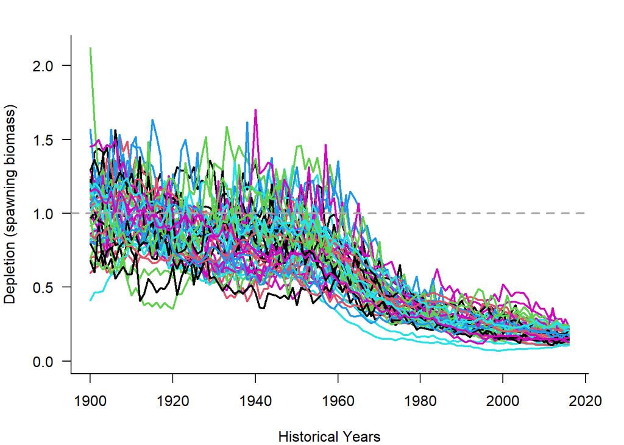

#### Absolute

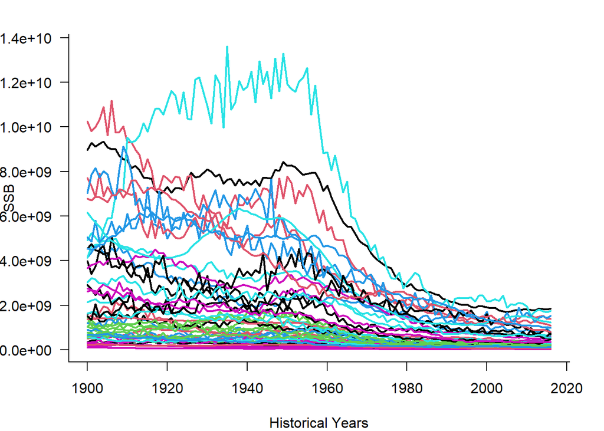

### Vulnerable Biomass

#### Depletion

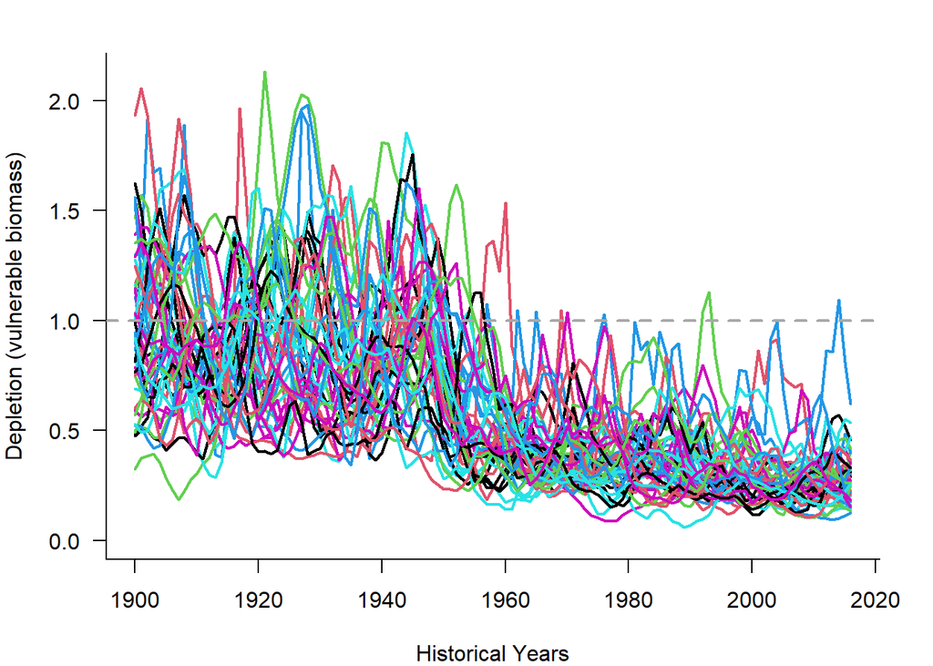

#### Absolute

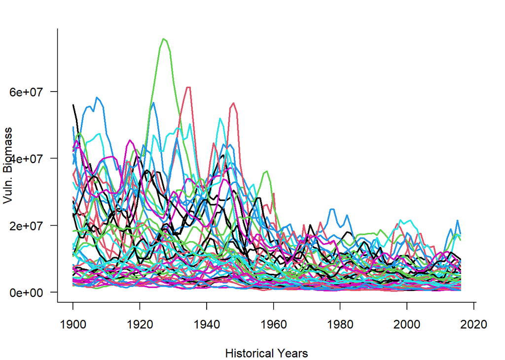

### Total Biomass

#### Depletion

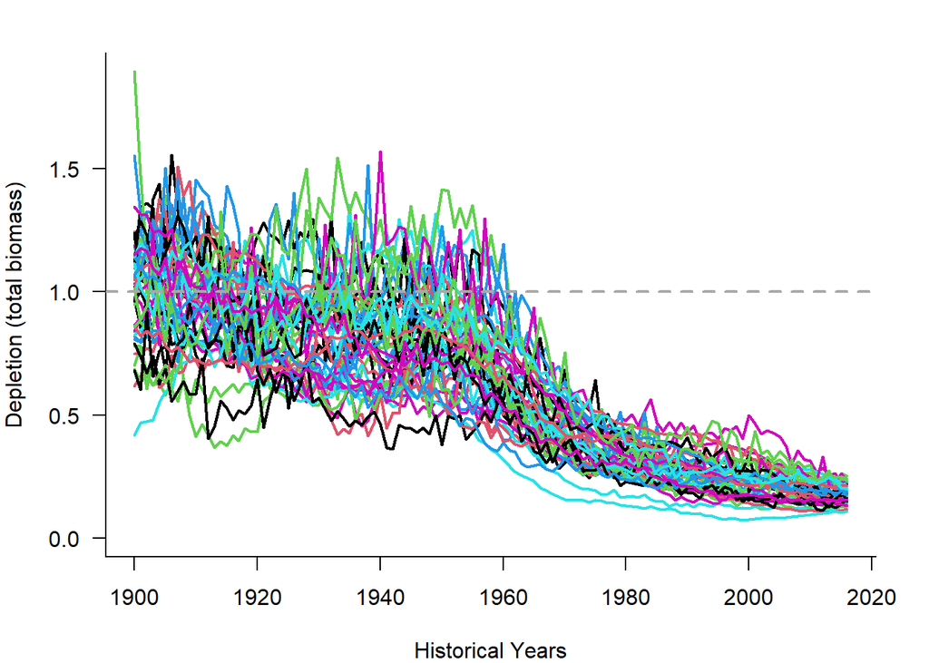

#### Absolute

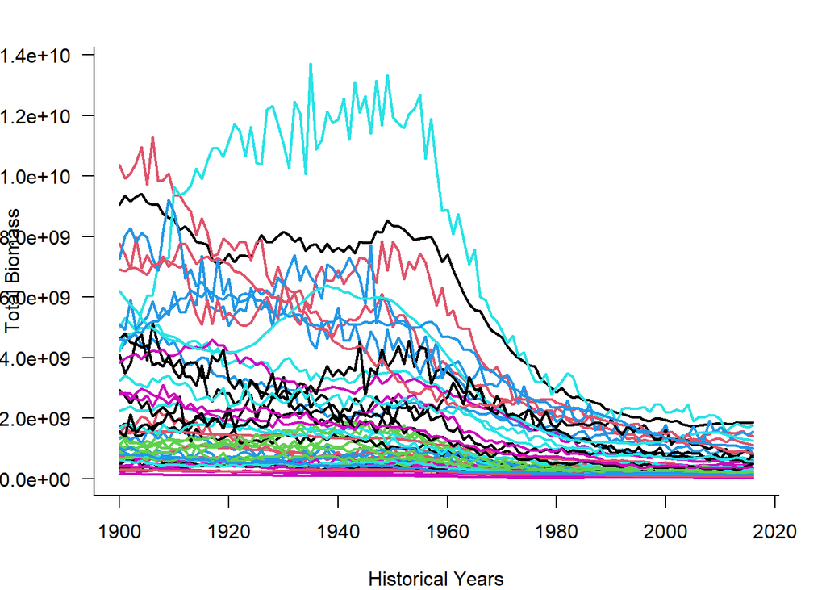

### Recruitment

#### Relative

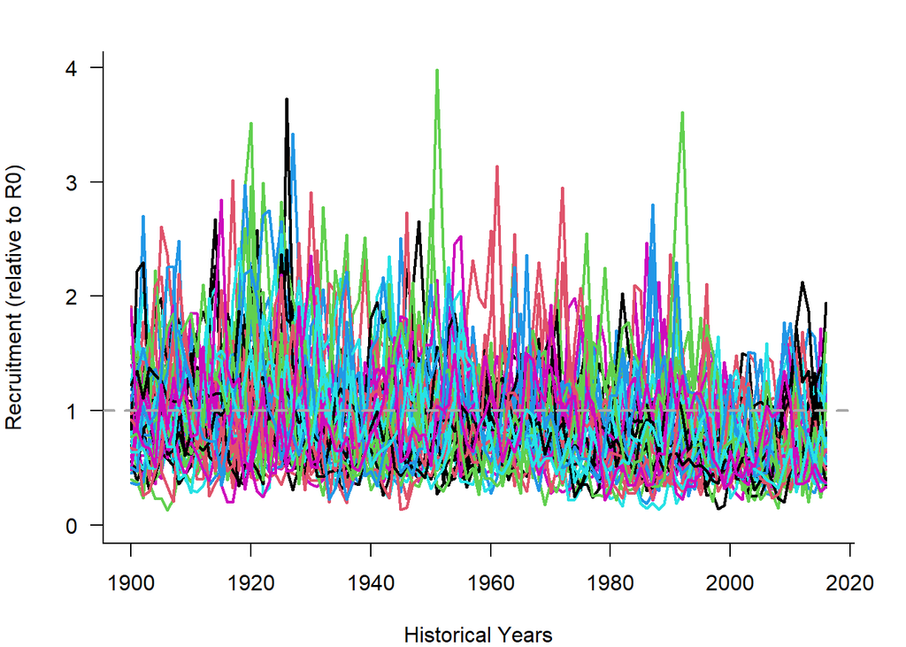

#### Absolute

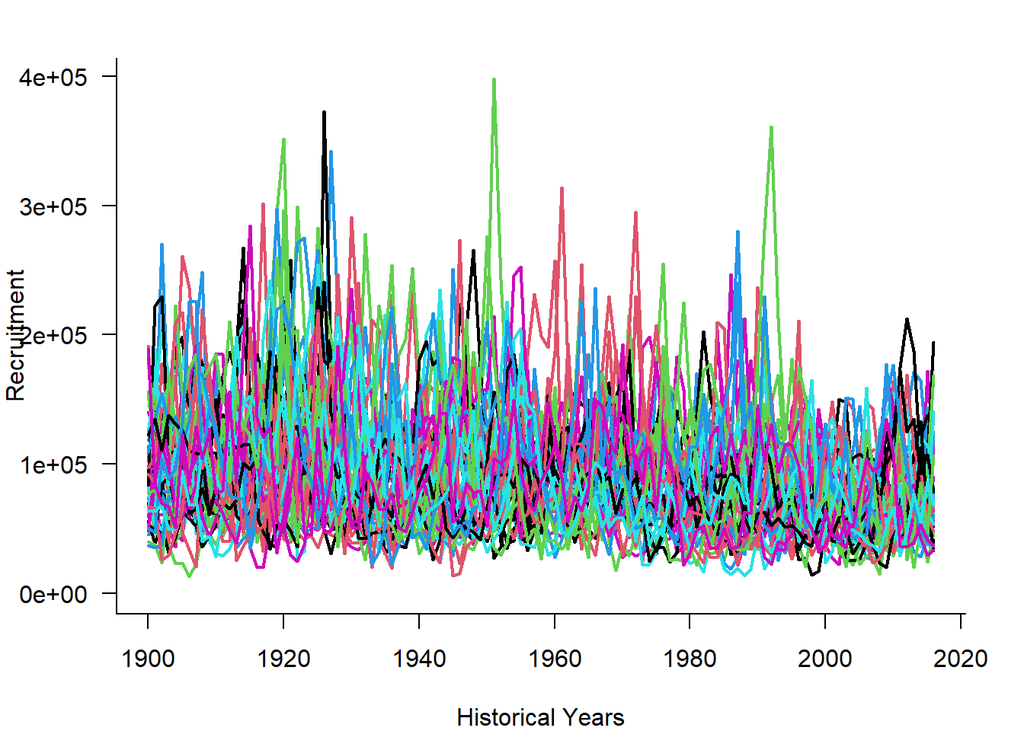

### Catch

#### Relative

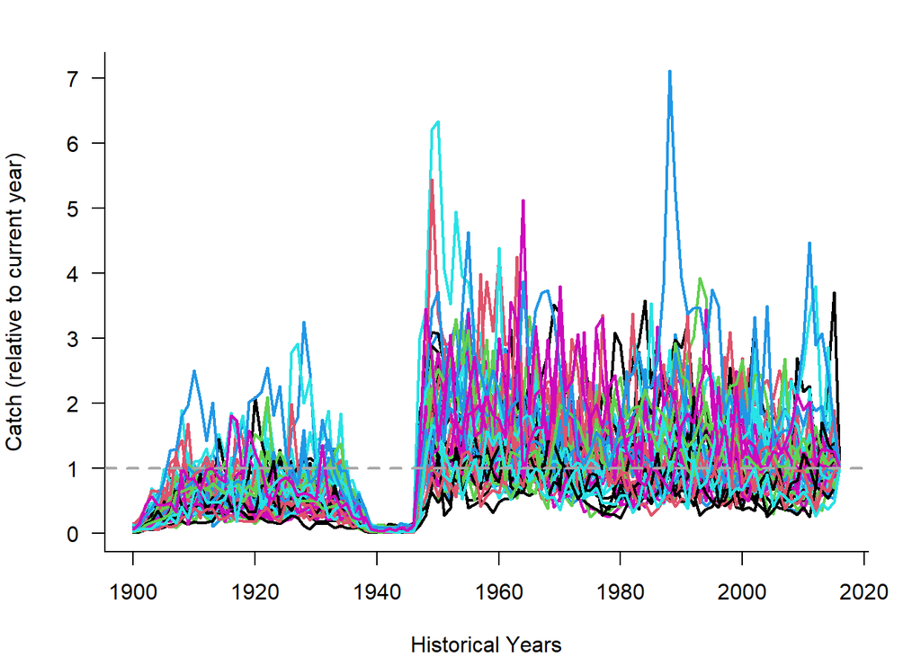

#### Absolute

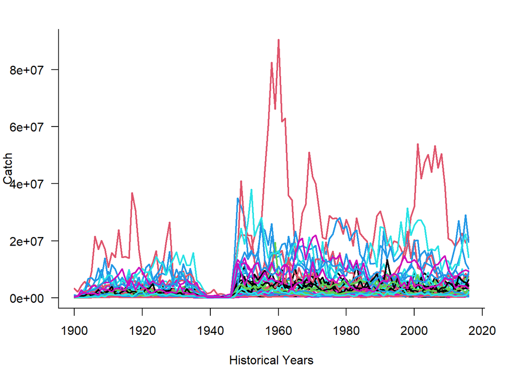

### Historical Fishing Mortality

#### Historical Time-Series

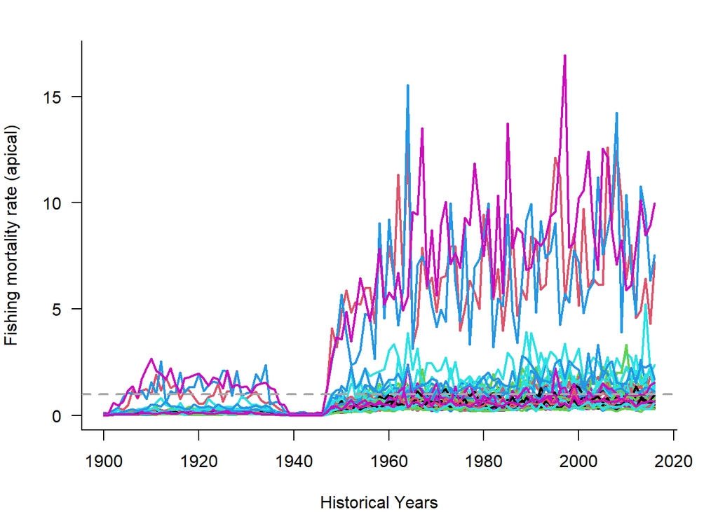

# References

Barnes, C.L., Starr, R.M., and Reilly, P.L. 2015. Growth, mortality, and reproductive seasonality of California halibut (Paralichthys californicus): A biogeographic approach.

Hoenig, J.M. 1983. Empirical use of longevity data to estimate mortality rates. Fish. Bull. 82:899–903

Love, M.S., and Brooks, A. 1990. Size and age at first maturity of the California halibut, Paralichthys californicus, in the Southern California Bight. In The California halibut, Paralichthys californicus, Resource and Fisheries. Edited by C.W. Haugen. California Department of Fish and Game, Fish Bulletin 174. pp. 167–174.

MacNair, L.S., Domeier, M.L., and Chun, C.S.Y. 2001. Age, growth, and mortality of California halibut, Paralichthys californicus, along southern and central California. Fish. Bull. 99: 588–600.

Maunder, M., Reilly, P., Tanaka, T., Schmidt, G., and Penttila, K. 2011. California Halibut Stock Assessment.

Pauly, D. 1980. On the interrelationships between natural mortality, growth parameters, and mean environmental temperature in 175 fish stocks. J Cons Int. Explor Mer. 39: 175–192.

Reed, R.R., and MacCall, A.D. 1988. Changing the size limit: How it could affect California halibut fisheries. Calif. Coop. Ocean. Fish. Investig. Reports 29: 158–166.

van der Veer, H.W., Freitas, V., and Leggett, W.C. 2015. Recruitment level and variability. In Flatfishes: biology and exploitation, 2nd edition. Edited by R.N. Gibson, R.D.M. Nash, A.J. Geffen, and H.W. van der Veer. Wiley Blackwell, Chichester, West Sussex. p. 542.